# Rを用いたデータ解析の 基礎と応用

※資料作成は岩嵜航さん（東北大学）にご協力いただきました。  
（左右キーで進みます！）

## 統計解析をしよう！

### 1. 課題を見つける／仮説を立てる

### 2. 実験や観察をしてデータを集める

### 3. **データを整理する**

### 4. **データを解析して仮説を検証する**

- 仮説の検証には科学的エビデンスが必要
- でも生物の表現型には ばらつきがある
  - 実験や観察で得られた差や効果は偶然の産物じゃないの？
- それに根拠を与えるのが統計解析！

## 知ってるかもしれないけど…

- 統計的に根拠のある差を 有意差という
  - アスタリスク(*)や異なるアルファベットで示される
  - 伝統的にp<0.05で「有意差がある」という
  - アスタリスクが多いほどp-valueが少ない
  - （「統計的な根拠」やp-valueの説明はのちほど）

## 母集団と標本

### **統計解析**

### **…標本に基づいて、母集団の性質を推定／仮説を検証する**

- 私たちが知りたいのは**母集団**の性質
- でも母集団の実測は不可能
- そこでランダムに抽出した標本から母集団の性質を**推定**する
  - 標本…実験で得られたデータなど
- 集団には**ばらつき**があるので毎回異なる値が得られる
- →ばらつきを考慮して母集団の性質を推定する

## 統計的仮説検定の考え方

### **帰無仮説**（例：２つの標本は**同じ母集団**由来）

### **対立仮説**（例：２つの標本は**異なる母集団**由来）

※帰無仮説と対立仮説は排他的

1. もし２つの標本が同じ母集団由来であった場合、今回得られた標本の差が生じる確率を計算する
2. この確率がすごく低い（<5%）場合、帰無仮説を棄却する
3. その結果、対立仮説を採用する

### つまり…**有意差がない ≠ 差がない**

- 統計的仮説検定の立場からはどちらとも言えない
- 態度を保留するのが正解

## 正しい解析法を使わないと意味がない

### 統計解析法にはそれぞれ**守るべき前提条件**がある

### →データの条件や目的に合った解析をしないと意味がない

### 有意差を求めて間違った解析法を使うのは**不正／不誠実**

### 自分のデータに合った解析を選べるようになろう！

- 今回は古典的な統計的仮説検定→統計モデリングの入口のみ
- より良い解析法を常に検討していく姿勢が大切！
  - より複雑なモデル、ベイズ統計など

## まずは統計的仮説検定をしてみよう！

### [penguins](https://allisonhorst.github.io/palmerpenguins/)で練習しよう

## 統計的仮説検定をしてみよう！

### 【復習】データを読み込んでざっくり眺める

```r
library(palmerpenguins)               #penguinsを読み込み
library(tidyverse)                    #tidyverseを読み込み
head(penguins)                        #penguinsの最初を見せて！
```

```
## # A tibble: 6 x 8
##   species island bill_length_mm bill_depth_mm flipper_length_… body_mass_g sex
##   <fct>   <fct>           <dbl>         <dbl>            <int>       <int> <fct>
## 1 Adelie  Torge…           39.1          18.7              181        3750 male
## 2 Adelie  Torge…           39.5          17.4              186        3800 fema…
## 3 Adelie  Torge…           40.3          18                195        3250 fema…
## 4 Adelie  Torge…           NA            NA                 NA          NA <NA>
## 5 Adelie  Torge…           36.7          19.3              193        3450 fema…
## 6 Adelie  Torge…           39.3          20.6              190        3650 male
## # … with 1 more variable: year <int>
```

- アデリーペンギンの体重に性差があるか？

## 統計的仮説検定をしてみよう！

### アデリーペンギンの体重に性差があるか？

### [練習問題]

- まずはデータをプロットしよう
  - 元データはpenguins
  - dplyrのfilterでspecies == “Adelie”だけ抽出
  - ggplot2でプロット
    - X軸…sex
    - Y軸…body_mass_g

## 統計的仮説検定をしてみよう！

### アデリーペンギンの体重に性差があるか？

```r
penguins_adelie = penguins %>%
  filter(species == "Adelie")
head(penguins_adelie)
```

```
## # A tibble: 6 x 8
##   species island bill_length_mm bill_depth_mm flipper_length_… body_mass_g sex
##   <fct>   <fct>           <dbl>         <dbl>            <int>       <int> <fct>
## 1 Adelie  Torge…           39.1          18.7              181        3750 male
## 2 Adelie  Torge…           39.5          17.4              186        3800 fema…
## 3 Adelie  Torge…           40.3          18                195        3250 fema…
## 4 Adelie  Torge…           NA            NA                 NA          NA <NA>
## 5 Adelie  Torge…           36.7          19.3              193        3450 fema…
## 6 Adelie  Torge…           39.3          20.6              190        3650 male
## # … with 1 more variable: year <int>
```

## 統計的仮説検定をしてみよう！

### アデリーペンギンの体重に性差があるか？

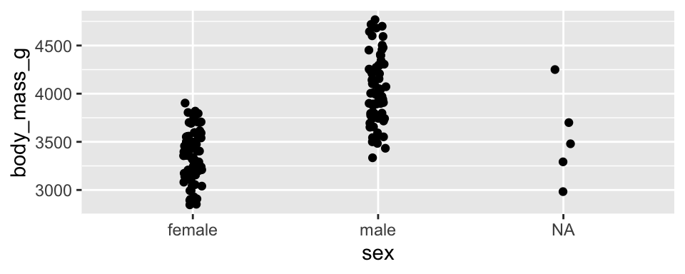

```r
gp = ggplot(data = penguins_adelie) +
  geom_point(aes(x = sex, y = body_mass_g),
             position = position_jitter(width = 0.05))
gp
```

- オスのほうが大きそう…！でもNAとかあるなぁ…

## 統計的仮説検定をしてみよう！

### アデリーペンギンの体重に性差があるか？

```r
penguins_adelie = penguins %>%
  filter(species == "Adelie", !is.na(sex)) #NAを除く
head(penguins_adelie)
```

```
## # A tibble: 6 x 8
##   species island bill_length_mm bill_depth_mm flipper_length_… body_mass_g sex
##   <fct>   <fct>           <dbl>         <dbl>            <int>       <int> <fct>
## 1 Adelie  Torge…           39.1          18.7              181        3750 male
## 2 Adelie  Torge…           39.5          17.4              186        3800 fema…
## 3 Adelie  Torge…           40.3          18                195        3250 fema…
## 4 Adelie  Torge…           36.7          19.3              193        3450 fema…
## 5 Adelie  Torge…           39.3          20.6              190        3650 male
## 6 Adelie  Torge…           38.9          17.8              181        3625 fema…
## # … with 1 more variable: year <int>
```

## 統計的仮説検定をしてみよう！

### アデリーペンギンの体重に性差があるか？

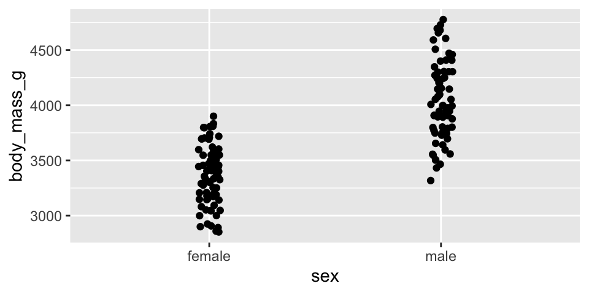

```r
gp = ggplot(data = penguins_adelie) +
  geom_point(aes(x = sex, y = body_mass_g),
             position = position_jitter(width = 0.05))
gp
```

- いい感じ！さて…

## 統計的仮説検定をしてみよう！

### 群間比較を行う（古典的）統計解析の進め方

1. データをプロットして眺める
2. 各標本に正規性があるか調べる
   - Q-Q plot
   - Shapiro-Wilkテスト
3. 等分散性はあるか調べる
   - Fテスト
4. 2, 3の結果を受けて検定方法を決め、検定する
   - 正規性/等分散性の有無で使える方法が違う
   - 各検定方法の前提条件をよく確認すること

## 統計的仮説検定をしてみよう！

### 1. 各標本に正規性があるか（**Q-Q plot**）

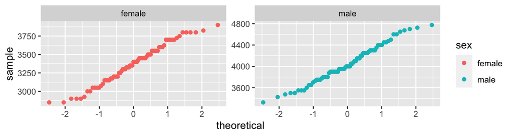

```r
gp = ggplot(data = penguins_adelie) +
       stat_qq(aes(sample = body_mass_g, color = sex)) +
       facet_wrap( ~ sex, scales = "free")
gp
```

- 正規Q-Q plotで直線上に乗っているような気がする

## 統計的仮説検定をしてみよう！

### 1. 各標本に正規性があるか

- **Shapiro-Wilkテスト**
  - shapiro.test(【調べたい標本】)
    - 【調べたい標本】はベクトルc(a, b, c…)で入れる
    - 【data.frame】$【列名】でも指定できる
  - 帰無仮説：正規性がある
  - p<0.05で正規性がないことを示す
  - （正規性があることは言えない）
  - １標本の値を入れる（**２標本を混ぜない**）

## 統計的仮説検定をしてみよう！

### 1. 各標本に正規性があるか（Shapiro-Wilkテスト）

```r
sw_test_results = penguins_adelie %>%   #penguins_adelieを使う
  group_by(sex) %>%                     #sexでグループ
  summarise(statistic = shapiro.test(body_mass_g)$statistic,
        #body_mass_gにshapiro.testを行い、そのstatistic値をstatisticという列に
            p.value = shapiro.test(body_mass_g)$p.value,    #同様
            .groups     = "drop") #グループを解除
head(sw_test_results)
```

```
## # A tibble: 2 x 3
##   sex    statistic p.value
##   <fct>      <dbl>   <dbl>
## 1 female     0.977   0.199
## 2 male       0.983   0.416
```

- 正規性がないとは言えない→「正規性あり」と判断

## 統計的仮説検定をしてみよう！

### 2. 等分散性があるか

- **Fテスト**
  - ベクトルとして
    - var.test(【標本A】, 【標本B】)
      - 標本はベクトルc(a, b, c…)で
  - データフレームとして
    - var.test(data = 【data.frame】, 【調べたい値の列名】~ 【グループ分けの列名】)
  - 帰無仮説：等分散性がある
  - p<0.05で等分散性がないことを示す

## 統計的仮説検定をしてみよう！

### 2. 等分散性があるか（Fテスト）

```r
var.test(data = penguins_adelie, body_mass_g ~ sex)
```

```
##
##  F test to compare two variances
##
## data:  body_mass_g by sex
## F = 0.60331, num df = 72, denom df = 72, p-value = 0.03356
## alternative hypothesis: true ratio of variances is not equal to 1
## 95 percent confidence interval:
##  0.3787186 0.9611059
## sample estimates:
## ratio of variances
##          0.6033147
```

- p<0.05なので「等分散性なし」と判断

## 統計的仮説検定をしてみよう！

### アデリーペンギンの体重に性差があるか？

- 正規性はあり
- 等分散性はなし
- 普通のt検定は使えない
- → Welchのt検定（正規性のみが前提条件）を使う

## 統計的仮説検定をしてみよう！

### 正規性あり等分散なしの２群の検定

- **Welchのt検定**
  - ベクトルとして
    - t.test(【標本A】, 【標本B】, var.equal = FALSE)
  - データフレームとして
    - t.test(data = 【data.frame】, 【調べたい値の列名】~ 【グループ分けの列名】, var.equal = FALSE)
  - 帰無仮説：平均が等しい
  - p<0.05で平均が異なる母集団に由来することを示す

## 統計的仮説検定をしてみよう！

### アデリーペンギンの体重に性差があるか？(Welchのt検定)

```r
t.test(data = penguins_adelie, body_mass_g ~ sex, var.equal = FALSE)
```

```
##
##  Welch Two Sample t-test
##
## data:  body_mass_g by sex
## t = -13.126, df = 135.69, p-value < 2.2e-16
## alternative hypothesis: true difference in means is not equal to 0
## 95 percent confidence interval:
##  -776.3012 -573.0139
## sample estimates:
## mean in group female   mean in group male
##             3368.836             4043.493
```

- 帰無仮説「平均が等しい」は棄却→有意差あり

## 統計的仮説検定をしてみよう！

### アデリーペンギンの体重に性差があるか？(Welchのt検定)

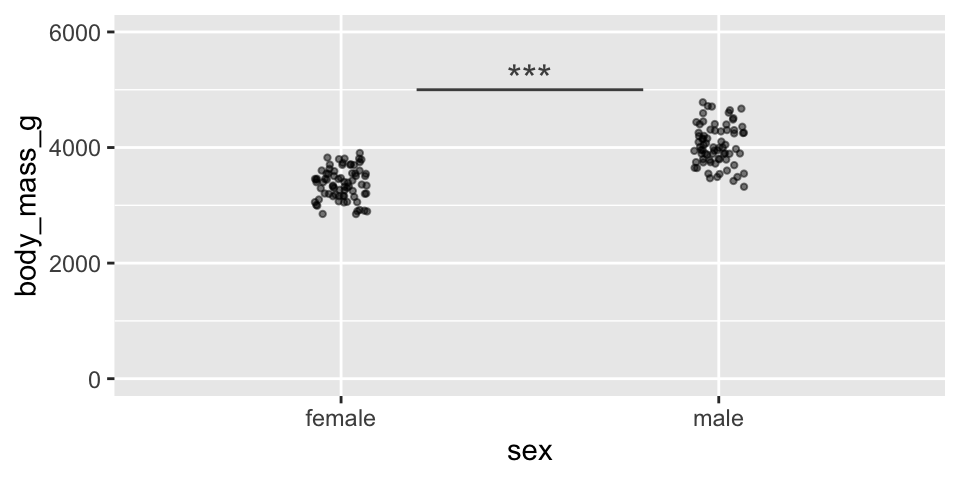

```r
gp = ggplot(data = penguins_adelie) +
  geom_point(aes(x = sex, y = body_mass_g), size = 0.8,
             position = position_jitter(width = 0.07), alpha = 0.5) +
  annotate("text", x = 1.5, y = 5200, label = "***", size = 5, color = "gray30") +
  annotate("segment", x = 1.2, xend = 1.8, y = 5000, yend = 5000, color = "gray30") +
  coord_cartesian(ylim = c(0, 6000))
gp
```

ようやくグラフが完成！

## 正規性のある２群の比較

### 等分散性あり→**Studentのt検定**

- t.test(data, Y ~ X, var.equal = TRUE)…デフォルト

### 等分散性なし→**Welchのt検定**

- t.test(data, Y ~ X, var.equal = FALSE)

### 対応なし

- t.test(data, Y ~ X, paired = FALSE)…デフォルト

### 対応あり

- t.test(data, Y ~ X, paired = TRUE)
  - 同じ個体から複数回データを取ったとき
    - 処理前と後を比較するときなど

## 正規性のある２群の比較

### ［練習問題］

- 等分散性があった場合の検定をしてみよう
- 対応ありだった場合の検定をしてみよう

## 正規性のある２群の比較

### ［練習問題］

- 等分散性があった場合の検定をしてみよう

```r
t.test(data = penguins_adelie, body_mass_g ~ sex, var.equal = TRUE)
```

```
##
##  Two Sample t-test
##
## data:  body_mass_g by sex
## t = -13.126, df = 144, p-value < 2.2e-16
## alternative hypothesis: true difference in means is not equal to 0
## 95 percent confidence interval:
##  -776.2484 -573.0666
## sample estimates:
## mean in group female   mean in group male
##             3368.836             4043.493
```

## 正規性のある２群の比較

### ［練習問題］

- 対応ありだった場合の検定をしてみよう

```r
t.test(data = penguins_adelie, body_mass_g ~ sex, paired = TRUE)
```

```
##
##  Paired t-test
##
## data:  body_mass_g by sex
## t = -14.264, df = 72, p-value < 2.2e-16
## alternative hypothesis: true difference in means is not equal to 0
## 95 percent confidence interval:
##  -768.944 -580.371
## sample estimates:
## mean of the differences
##               -674.6575
```

## 統計的仮説検定をしてみよう！

### くちばしの形は雌雄で異なるか？

[figure not shown]

## 統計的仮説検定をしてみよう！

### くちばしの細長さは雌雄で異なるか？

### [練習問題]

- アデリーペンギンのくちばしの細長さを計算しよう
- 計算できたらプロットしてみよう

## 統計的仮説検定をしてみよう！

### くちばしの細長さは雌雄で異なるか？

### [練習問題]

```r
penguins_adelie = penguins %>%
  filter(species == "Adelie", !is.na(sex)) %>% #NAを除く
  mutate(ratio = bill_depth_mm/bill_length_mm)
head(penguins_adelie)
```

```
## # A tibble: 6 x 9
##   species island bill_length_mm bill_depth_mm flipper_length_… body_mass_g sex
##   <fct>   <fct>           <dbl>         <dbl>            <int>       <int> <fct>
## 1 Adelie  Torge…           39.1          18.7              181        3750 male
## 2 Adelie  Torge…           39.5          17.4              186        3800 fema…
## 3 Adelie  Torge…           40.3          18                195        3250 fema…
## 4 Adelie  Torge…           36.7          19.3              193        3450 fema…
## 5 Adelie  Torge…           39.3          20.6              190        3650 male
## 6 Adelie  Torge…           38.9          17.8              181        3625 fema…
## # … with 2 more variables: year <int>, ratio <dbl>
```

## 統計的仮説検定をしてみよう！

### くちばしの細長さは雌雄で異なるか？

### [練習問題]

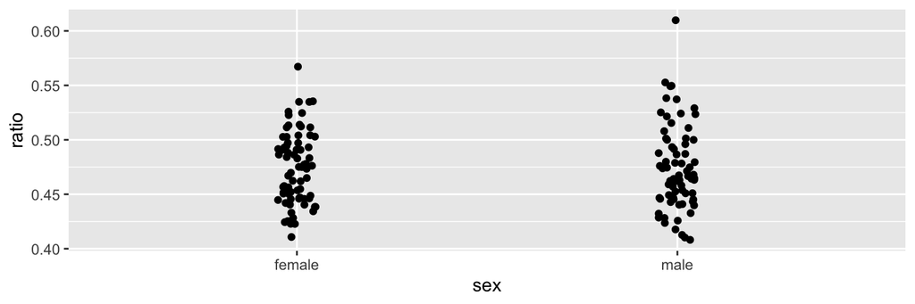

```r
gp = ggplot(data = penguins_adelie) +
  geom_point(aes(x = sex, y = ratio),
             position = position_jitter(width = 0.05))
gp
```

## 統計的仮説検定をしてみよう！

### くちばしの細長さは雌雄で異なるか？

### 1. 各標本に正規性はあるか（**Q-Q plot**）

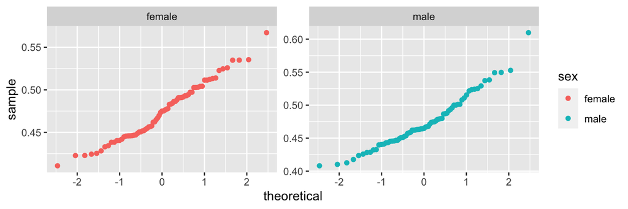

```r
gp = ggplot(data = penguins_adelie) +
       stat_qq(aes(sample = ratio, color = sex)) +
       facet_wrap( ~ sex, scales = "free")
gp
```

## 統計的仮説検定をしてみよう！

### くちばしの細長さは雌雄で異なるか？

### 1. 各標本に正規性はあるか（Shapiro-Wilkテスト）

```r
sw_test_results = penguins_adelie %>%   #penguins_adelieを使う
  group_by(sex) %>%                     #sexでグループ
  summarise(statistic = shapiro.test(ratio)$statistic,
        #ratioにshapiro.testを行い、そのstatistic値をstatisticという列に
            p.value = shapiro.test(ratio)$p.value,    #同様
            .groups     = "drop") #グループを解除
head(sw_test_results)
```

```
## # A tibble: 2 x 3
##   sex    statistic p.value
##   <fct>      <dbl>   <dbl>
## 1 female     0.975 0.164
## 2 male       0.954 0.00962
```

## 統計的仮説検定をしてみよう！

### くちばしの細長さは雌雄で異なるか？

### 2. 等分散性があるか（Fテスト）

```r
var.test(data = penguins_adelie, ratio ~ sex)
```

```
##
##  F test to compare two variances
##
## data:  ratio by sex
## F = 0.73443, num df = 72, denom df = 72, p-value = 0.1928
## alternative hypothesis: true ratio of variances is not equal to 1
## 95 percent confidence interval:
##  0.4610261 1.1699847
## sample estimates:
## ratio of variances
##          0.7344341
```

## 統計的仮説検定をしてみよう！

### くちばしの細長さは雌雄で異なるか？

- 正規性はなし
- 等分散性はあり
- 対応はない
- → Wilcoxonの順位和検定（U検定と同じ）を行う

## 統計的仮説検定をしてみよう！

### 正規性なし等分散性ありの２群の比較

- **Wilcoxonの順位和検定**
  - デフォルトのwilcox.test()ではタイ値があると正確なp値が出ないので[coin](https://cran.r-project.org/web/packages/exactRankTests/index.html)パッケージを使う
    - ベクトルとして
      - wilcox_test(【標本A】, 【標本B】, distribution = “exact”)
    - データフレームとして
      - wilcox_test(data = 【data.frame】, 【調べたい値の列名】~ 【グループ分けの列名】, distribution = “exact”)
  - 帰無仮説：２群間に差がない
  - p<0.05で異なる母集団に由来することを示す

## 統計的仮説検定をしてみよう！

### くちばしの細長さは雌雄で異なるか？

まずinstall.packages(“coin”)

```r
library(coin)             # 読み込み
wilcox_test(data = penguins_adelie, ratio ~ sex, distribution = "exact")
```

```
##
##  Exact Wilcoxon-Mann-Whitney Test
##
## data:  ratio by sex (female, male)
## Z = 0.29941, p-value = 0.7661
## alternative hypothesis: true mu is not equal to 0
```

- 帰無仮説「２群間に差がない」は棄却されない→有意差なし

## 正規性なし、等分散性ありの２群の比較

### 対応なし→**Wilcoxonの順位和検定**

- wilcox_test(data, Y ~ X, distribution = “exact”)

### 対応あり→**Wilcoxonの符号順位検定**

- wilcoxsign_test(data, Y ~ X, distribution = “exact”)

## 正規性なし、等分散性なしの２群の比較

- **Brunner-Munzel検定**
  - [brunnermunzel](https://cran.r-project.org/web/packages/brunnermunzel/index.html)パッケージを使う
  - ベクトルとして
    - brunnermunzel.test(【標本A】, 【標本B】)
  - データフレームとして
    - brunnermunzel.test(data = 【data.frame】, 【調べたい値の列名】~ 【グループ分けの列名】)
  - 帰無仮説：２群が等しい
  - p<0.05で平均が異なる母集団に由来することを示す
  - 「サンプル数が少ない」というエラーが出たらbrunnermunzel.permutation.test

## 統計的仮説検定をしてみよう！

### さっきのデータで使ってみよう

まずinstall.packages(“brunnermunzel”)

```r
library(brunnermunzel)             # 読み込み
brunnermunzel.test(data = penguins_adelie, ratio ~ sex)
```

```
##
##  Brunner-Munzel Test
##
## data:  ratio by sex
## Brunner-Munzel Test Statistic = -0.29701, df = 143.58, p-value = 0.7669
## 95 percent confidence interval:
##  0.3901081 0.5811811
## sample estimates:
## P(X<Y)+.5*P(X=Y)
##        0.4856446
```

## 【まとめ】１要因２群間の検定法

1. まずはプロット
2. 正規性, 等分散性, 対応あり/なしを確認
   - Q-Q plot, Shapiro-Wilkテスト
   - F検定
3. 検定方法を決める
   - Studentのt検定（対応あり／なし）
   - Welchのt検定（対応あり／なし）
   - Wilcoxonの順位和検定
   - Wilcoxonの符号順位検定
   - Brunner-Munzel検定（対応あり／なし）

## 多群（３群以上）の比較をしよう

### **2群の比較を単に繰り返すのはダメ**

- 仮説検定の考え方を思い出そう
1. 同じ母集団由来であった場合に今回得られた標本の差が生じる確率が低い（<5%）→帰無仮説を棄却する
2. その結果、対立仮説を採用する

### **どこかで有意差が出る確率はどんどん高まる**

- 100回検定すれば5回は偶然有意差が出る

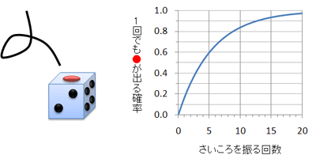

  [阪大医学・老年・腎臓内科学HP](https://www.med.osaka-u.ac.jp/pub/kid/clinicaljournalclub1.html)

## 多群（３群以上）の比較をしよう

### 有意差があった群のみ検定したことにする？

### →もちろん**不正**！！

### 多重比較法を使うか、有意水準を補正する

- 今回は多重比較を紹介します
- 有意水準の補正の方法は[こちら](https://oku.edu.mie-u.ac.jp/~okumura/stat/multiplecomparisons.html)など

## 多群（３群以上）の比較をしよう

### 【復習】読み込んでデータをざっくり眺める

```r
library(palmerpenguins)               #penguinsを読み込み
library(tidyverse)                    #tidyverseを読み込み
head(penguins)                        #penguinsの最初を見せて！
```

```
## # A tibble: 6 x 8
##   species island bill_length_mm bill_depth_mm flipper_length_… body_mass_g sex
##   <fct>   <fct>           <dbl>         <dbl>            <int>       <int> <fct>
## 1 Adelie  Torge…           39.1          18.7              181        3750 male
## 2 Adelie  Torge…           39.5          17.4              186        3800 fema…
## 3 Adelie  Torge…           40.3          18                195        3250 fema…
## 4 Adelie  Torge…           NA            NA                 NA          NA <NA>
## 5 Adelie  Torge…           36.7          19.3              193        3450 fema…
## 6 Adelie  Torge…           39.3          20.6              190        3650 male
## # … with 1 more variable: year <int>
```

- ペンギンの体重は種ごとに異なるか？

## 多群（３群以上）の比較をしよう

### ペンギンの体重は種ごとに異なるか？

- 体重に性差があるのでメスに限定して調べよう
- まずはデータをプロットしよう

```r
penguins_female = penguins %>%
  filter(sex == "female")
head(penguins_female)
```

```
## # A tibble: 6 x 8
##   species island bill_length_mm bill_depth_mm flipper_length_… body_mass_g sex
##   <fct>   <fct>           <dbl>         <dbl>            <int>       <int> <fct>
## 1 Adelie  Torge…           39.5          17.4              186        3800 fema…
## 2 Adelie  Torge…           40.3          18                195        3250 fema…
## 3 Adelie  Torge…           36.7          19.3              193        3450 fema…
## 4 Adelie  Torge…           38.9          17.8              181        3625 fema…
## 5 Adelie  Torge…           41.1          17.6              182        3200 fema…
## 6 Adelie  Torge…           36.6          17.8              185        3700 fema…
## # … with 1 more variable: year <int>
```

## 多群（３群以上）の比較をしよう

### ペンギンの体重は種ごとに異なるか？

- まずはデータをプロットしよう

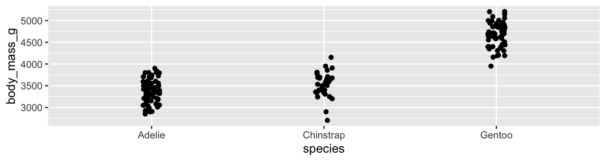

```r
gp = ggplot(data = penguins_female) +
  geom_point(aes(x = species, y = body_mass_g),
             position = position_jitter(width = 0.05))
gp
```

- 差がありそうな雰囲気…！

## 多群（３群以上）の比較をしよう

### ３群以上の比較を行うときも進め方は同じ

1. データをプロットして眺める
2. 各標本に正規性があるか調べる
   - Q-Q plot
   - Shapiro-Wilkテスト
3. 等分散性はあるか調べる
   - Bartlettテスト ←Fテストの多群版
4. 2, 3の結果を受けて検定方法を決め、検定する

## 多群（３群以上）の比較をしよう

### 1. 各標本に正規性はあるか（**Q-Q plot**）

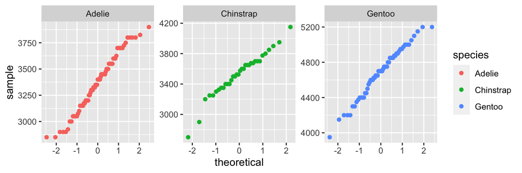

```r
gp = ggplot(data = penguins_female) +
  stat_qq(aes(sample = body_mass_g, color = species)) +
  facet_wrap( ~ species, scales = "free")
gp
```

- 正規Q-Q plotで直線上に乗っているような気がする

## 多群（３群以上）の比較をしよう

### 1. 各標本に正規性はあるか（Shapiro-Wilkテスト）

```r
sw_test_results = penguins_female %>%   #penguins_adelieを使う
  group_by(species) %>%                     #speciesでグループ
  summarise(statistic = shapiro.test(body_mass_g)$statistic,
        #body_mass_gにshapiro.testを行い、そのstatistic値をstatisticという列に
            p.value = shapiro.test(body_mass_g)$p.value,    #同様
            .groups     = "drop") #グループを解除
head(sw_test_results)
```

```
## # A tibble: 3 x 3
##   species   statistic p.value
##   <fct>         <dbl>   <dbl>
## 1 Adelie        0.977   0.199
## 2 Chinstrap     0.963   0.306
## 3 Gentoo        0.981   0.511
```

- 「正規性あり」と判断

## 多群（３群以上）の比較をしよう

### 2. 等分散性があるか

- **Bartlettテスト**
  - ベクトルとして
    - bartlett.test(x = list(A, B, C))
  - データフレームとして
    - bartlett.test(data = 【data.frame】, 【調べたい値の列名】~ 【グループ分けの列名】)
  - 帰無仮説：等分散性がある
  - p<0.05で等分散性がないことを示す

## 多群（３群以上）の比較をしよう

### 2. 等分散性があるか（Bartlettテスト）

```r
bartlett.test(data = penguins_female, body_mass_g ~ species)
```

```
##
##  Bartlett test of homogeneity of variances
##
## data:  body_mass_g by species
## Bartlett's K-squared = 0.19828, df = 2, p-value = 0.9056
```

- 「等分散性あり」と判断

## 多群（３群以上）の比較をしよう

### ペンギンの体重は種ごとに異なるか？

- 正規性あり
- 等分散性あり
- ３群以上
- → 一元分散分析（ANOVA）を使う

## 多群（３群以上）の比較をしよう

### 正規性あり等分散性ありの多群比較

- **一元分散分析（ANOVA）**
  - summary(aov(data = 【data.frame】, 【調べたい値の列名】~ 【グループ分けの列名】))
  - 帰無仮説：全ての群が同一の母集団に由来する（=全ての群に差がない）
  - p<0.05で異なる母集団に由来することを示す

## 多群（３群以上）の比較をしよう

### ペンギンの体重は種ごとに異なるか？

```r
summary(aov(data = penguins_female, body_mass_g ~ species))
```

```
##              Df   Sum Sq  Mean Sq F value Pr(>F)
## species       2 60350016 30175008   393.2 <2e-16 ***
## Residuals   162 12430757    76733
## ---
## Signif. codes:  0 '***' 0.001 '**' 0.01 '*' 0.05 '.' 0.1 ' ' 1
```

- 有意差はある
- 帰無仮説（群間に差がない）は棄却された
- どのペアに差があるのか？
  - post-hocテストを行う

## 多群（３群以上）の比較をしよう

### 正規性あり等分散性ありの多群比較のpost-hocテスト

- **Tukeyの多重比較**
  - TukeyHSD(aov(data = 【data.frame】, 【調べたい値の列名】~ 【グループ分けの列名】))
  - 帰無仮説：２群間に差がない
  - p<0.05で異なる母集団に由来することを示す

## 多群（３群以上）の比較をしよう

### ペンギンの体重は種ごとに異なるか？

```r
TukeyHSD(aov(data = penguins_female, body_mass_g ~ species))
```

```
##   Tukey multiple comparisons of means
##     95% family-wise confidence level
##
## Fit: aov(formula = body_mass_g ~ species, data = penguins_female)
##
## $species
##                       diff        lwr       upr     p adj
## Chinstrap-Adelie  158.3703   22.32078  294.4197 0.0179471
## Gentoo-Adelie    1310.9058 1195.64908 1426.1624 0.0000000
## Gentoo-Chinstrap 1152.5355 1011.00620 1294.0648 0.0000000
```

## 多群（３群以上）の比較をしよう

### ペンギンの体重は種ごとに異なるか？

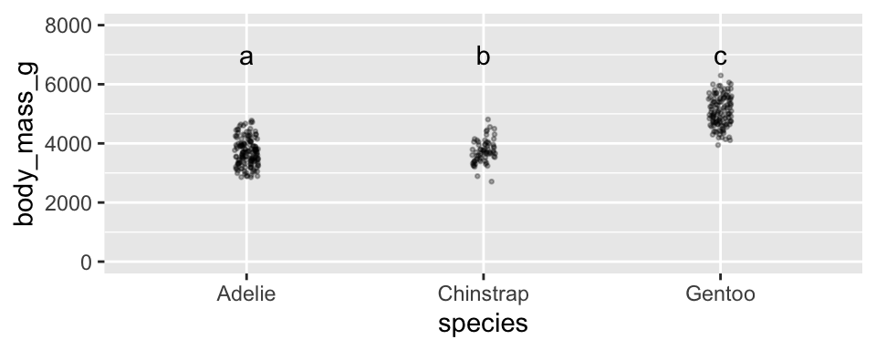

```r
gp = ggplot(data = penguins) +
  geom_point(aes(x = species, y = body_mass_g), size = 0.5,
             position = position_jitter(width = 0.05), alpha = 0.3) +
  annotate("text", x = c(1, 2, 3), y = 7000, label = c("a", "b", "c")) +
  coord_cartesian(ylim = c(0, 8000))
gp
```

できあがり！

## 多群（３群以上）の比較をしよう

### 正規性なし、等分散性ありの場合は…

- **Kruscal-Wallis検定**
  - kruskal.test(data = 【data.frame】, 【調べたい値の列名】~ 【グループ分けの列名】)
  - 帰無仮説：全ての群に差がない
  - p<0.05で異なる母集団に由来することを示す
  - ただし近似のp値を計算するのでサンプルサイズが小さい場合は注意

## 多群（３群以上）の比較をしよう

### post-hocは…

- **Steel-Dwass検定**
  - [NSM3](https://cran.r-project.org/web/packages/NSM3/index.html)パッケージを使う
  - pSDCFlig(【調べたい値をベクトルで】, 【グループ分けをベクトルで】, method = 【方法】)
    - methodは３種類
      - “Exact”…正確
      - “Asymptotic”… 漸近
      - “Monte Carlo”…モンテカルロ法
        - 正確以外の場合はサンプルサイズに注意
  - 帰無仮説：２群間に差がない
  - p<0.05で異なる母集団に由来することを示す

## 多群（３群以上）の比較をしよう

### ペンギンの体重は種ごとに異なるか？（Kruscal-Wallis）

```r
kruskal.test(data = penguins_female, body_mass_g ~ species)
```

```
##
##  Kruskal-Wallis rank sum test
##
## data:  body_mass_g by species
## Kruskal-Wallis chi-squared = 115.24, df = 2, p-value < 2.2e-16
```

## 多群（３群以上）の比較をしよう

### ペンギンの体重は種ごとに異なるか？（Steel-Dwass）

まずinstall.package(“NSM3”)

```r
library(NSM3)
pSDCFlig(penguins_female$body_mass_g, penguins_female$species, method = "Asymptotic")
```

```
## Ties are present, so p-values are based on conditional null distribution.
## Group sizes: 73 34 58
## Using the Asymptotic method:
##
## For treatments Adelie - Chinstrap, the Dwass, Steel, Critchlow-Fligner W Statistic is 3.8595.
## The smallest experimentwise error rate leading to rejection is 0.0175 .
##
## For treatments Adelie - Gentoo, the Dwass, Steel, Critchlow-Fligner W Statistic is 13.877.
## The smallest experimentwise error rate leading to rejection is 0 .
##
## For treatments Chinstrap - Gentoo, the Dwass, Steel, Critchlow-Fligner W Statistic is 11.2606.
## The smallest experimentwise error rate leading to rejection is 0 .
##
```

## 【まとめ】１要因多群間の検定法

1. まずはプロット
2. 正規性, 等分散性, 対応あり/なしを確認
   - Q-Q plot, Shapiro-Wilkテスト
   - Bartlettテスト
3. 検定方法を決める
   - ANOVA → Tukey
   - Kruscal-Wallis → Steel-Dwass

### ２要因の場合は…

- Two-way ANOVAやFriedman検定など

## 統計的仮説検定から統計モデリングへ

### 統計的仮説検定は古くから用いられている方法

### だけどこれだとうまく解析できないことも…

- 例えば値と値の関係性とか、複数の要因が絡み合うとき

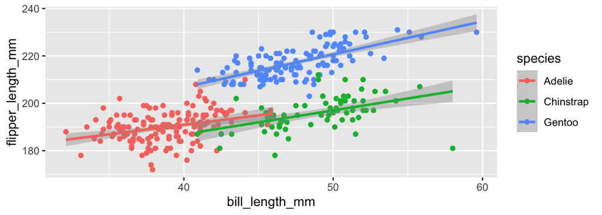

### →こういうときは統計モデリングが適している

## モデリングで値の関係性を調べよう

### 【復習】データを読み込んでざっくり眺める

```r
library(palmerpenguins)               #penguinsを読み込み
library(tidyverse)                    #tidyverseを読み込み
head(penguins)                        #penguinsの最初を見せて！
```

```
## # A tibble: 6 x 8
##   species island bill_length_mm bill_depth_mm flipper_length_… body_mass_g sex
##   <fct>   <fct>           <dbl>         <dbl>            <int>       <int> <fct>
## 1 Adelie  Torge…           39.1          18.7              181        3750 male
## 2 Adelie  Torge…           39.5          17.4              186        3800 fema…
## 3 Adelie  Torge…           40.3          18                195        3250 fema…
## 4 Adelie  Torge…           NA            NA                 NA          NA <NA>
## 5 Adelie  Torge…           36.7          19.3              193        3450 fema…
## 6 Adelie  Torge…           39.3          20.6              190        3650 male
## # … with 1 more variable: year <int>
```

- 体重の大きいペンギンは翼長も長い？

## モデリングで値の関係性を調べよう

### 体重の大きいペンギンは翼長も長い？

- まずはデータをプロットしよう

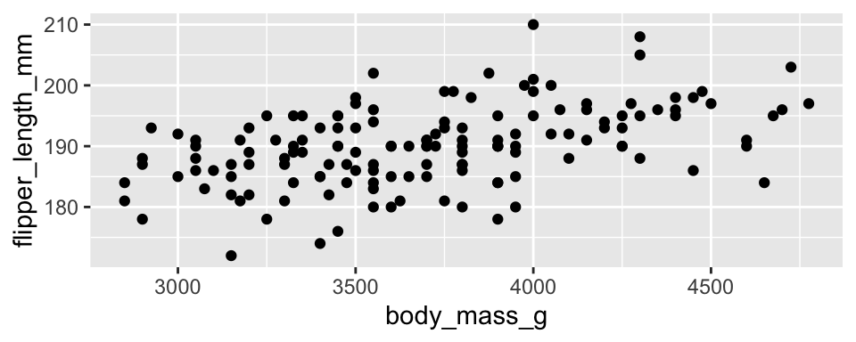

```r
gp = ggplot(data = penguins_adelie) +
  geom_point(aes(x = body_mass_g, y = flipper_length_mm))
gp
```

- 微妙な傾向はありそう…統計的にはどうか？

## モデリングで値の関係性を調べよう

### **単回帰分析**

- 1つの要因が1つの結果を与えるシンプルな因果関係を説明する
- 前提：目的変数は正規分布に従う

### **一般化線形モデル（Generalized linear model, GLM）**

- 説明変数と目的変数間の関係を説明するモデリング手法
- 前提：目的変数は正規分布、二項分布、ポアソン分布など  
  引用：[biostatics](https://stats.biopapyrus.jp/)

## モデリングで値の関係性を調べよう

### **単回帰分析**

- Y ~ β0 + β1X
  - 確率変数X：説明変数（独立変数）
  - 確率変数Y：目的変数（従属変数）
- 最小二乗法によって残差が最小になるβ0とβ1を求める

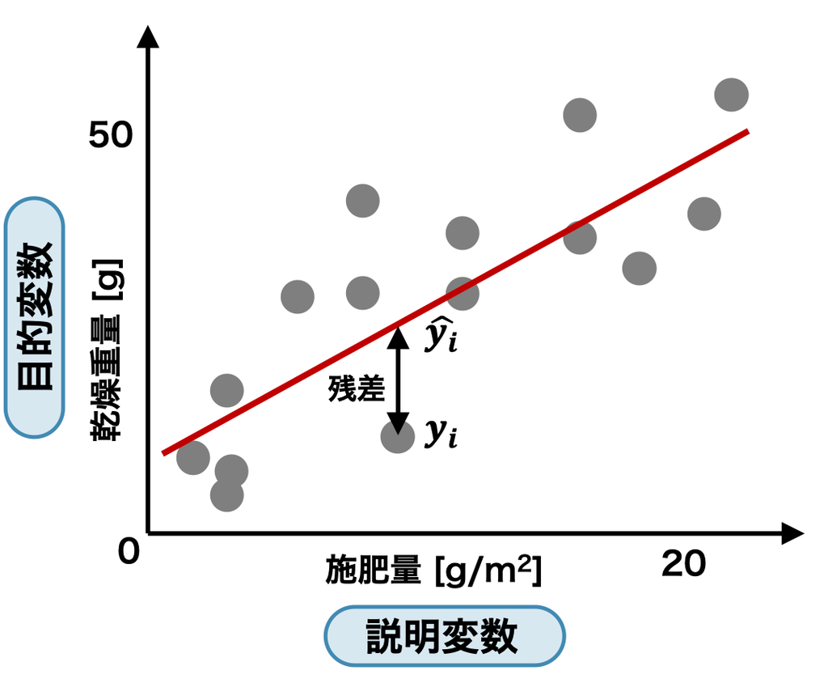

  引用：[biostatics](https://stats.biopapyrus.jp/)

## モデリングで値の関係性を調べよう

### **単回帰分析**

- lm(data =【data.frame】,【目的変数の列名】~【説明変数の列名】)
  - lmは線形モデル（linear model）
  - 前提：目的変数は正規分布に従う

## モデリングで値の関係性を調べよう

### 目的変数（翼長）は正規分布に従うか

```r
shapiro.test(penguins_adelie$flipper_length_mm)
```

```
##
##  Shapiro-Wilk normality test
##
## data:  penguins_adelie$flipper_length_mm
## W = 0.9934, p-value = 0.7427
```

- 「正規性あり」と判断

## モデリングで値の関係性を調べよう

### 体重の大きいペンギンは翼長も長い？（単回帰分析）

```r
lm_result = lm(flipper_length_mm ~ body_mass_g, data = penguins_adelie)
                         #結果をlm_resultに入れる
summary(lm_result)       #lm_resultの詳細を表示する
```

```
##
## Call:
## lm(formula = flipper_length_mm ~ body_mass_g, data = penguins_adelie)
##
## Residuals:
##     Min      1Q  Median      3Q     Max
## -14.426  -3.669   0.239   3.422  17.955
##
## Coefficients:
##              Estimate Std. Error t value Pr(>|t|)
## (Intercept) 1.656e+02  3.918e+00   42.27  < 2e-16 ***
## body_mass_g 6.610e-03  1.049e-03    6.30  3.4e-09 ***
## ---
## Signif. codes:  0 '***' 0.001 '**' 0.01 '*' 0.05 '.' 0.1 ' ' 1
##
## Residual standard error: 5.794 on 144 degrees of freedom
## Multiple R-squared:  0.2161, Adjusted R-squared:  0.2106
## F-statistic: 39.69 on 1 and 144 DF,  p-value: 3.402e-09
```

## モデリングで値の関係性を調べよう

### 体重の大きいペンギンは翼長も長い？（単回帰分析）

- Coefficients: 回帰係数
  - Estimates: 推定値
    - (Intercept): 切片
    - body_mass_g: body_mass_gの係数
  - Pr(>|t|): 回帰係数が0であるという帰無仮説に対するp値。
- Multiple R-squared: 決定係数。lmの場合はXとYの相関係数の2乗。1に近づくほどデータをよく説明している。決定係数が高いときは「モデルの説明力が高い」。
- ということは…
- Estimated coefficients of body_mass_g: 6.610e-03
- Pr(>|t|): 3.4e-09
- Multiple R-squared: 0.2161
- →翼長への体サイズの効果は有意である（効果量は低いけどね）

## モデリングで値の関係性を調べよう

### ggplotで描画もできる（geom_smooth, method = “lm”）

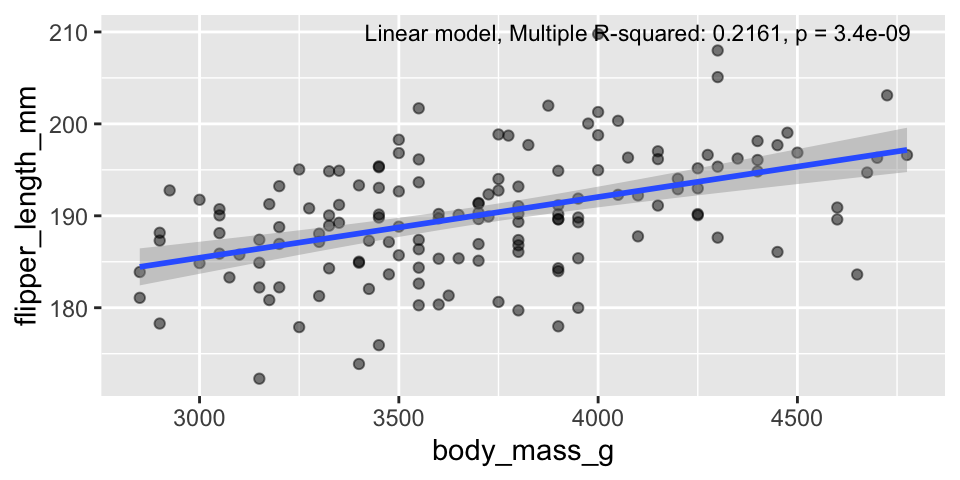

```r
gp = ggplot(data = penguins_adelie) +
  geom_point(aes(x = body_mass_g, y = flipper_length_mm),
             position = position_jitter(width = 0.05), alpha = 0.5)  +
  geom_smooth(aes(x = body_mass_g, y = flipper_length_mm), method = "lm")  +
                                                              #lmで回帰した直線を引く
  annotate("text", x = 4100, y = 210,
           label = "Linear model, Multiple R-squared: 0.2161, p = 3.4e-09", size = 3)
gp
```

## モデリングで値の関係性を調べよう

### 性を考慮したらもう少しうまく説明できる？

### **重回帰分析**

- lm(data = 【data.frame】, 【目的変数の列名】~【説明変数１の列名】+【説明変数２の列名】)
  - 前提
    - 目的変数は正規分布に従う
    - 説明変数同士は独立である（相関関係などがない）
  - 有意でない説明変数はモデルから取り除く

## モデリングで値の関係性を調べよう

### 翼長は体重と性で説明できるか？（重回帰分析）

```r
lm_result = lm(flipper_length_mm ~ body_mass_g + sex, data = penguins_adelie)
                         #結果をlm_resultに入れる
summary(lm_result)       #lm_resultの詳細を表示する
```

```
##
## Call:
## lm(formula = flipper_length_mm ~ body_mass_g + sex, data = penguins_adelie)
##
## Residuals:
##      Min       1Q   Median       3Q      Max
## -14.4087  -3.5229   0.1197   3.3750  17.8645
##
## Coefficients:
##              Estimate Std. Error t value Pr(>|t|)
## (Intercept) 1.665e+02  5.300e+00  31.410  < 2e-16 ***
## body_mass_g 6.333e-03  1.560e-03   4.059 8.08e-05 ***
## sexmale     3.440e-01  1.426e+00   0.241     0.81
## ---
## Signif. codes:  0 '***' 0.001 '**' 0.01 '*' 0.05 '.' 0.1 ' ' 1
##
## Residual standard error: 5.813 on 143 degrees of freedom
## Multiple R-squared:  0.2164, Adjusted R-squared:  0.2054
## F-statistic: 19.75 on 2 and 143 DF,  p-value: 2.676e-08
```

## モデリングで値の関係性を調べよう

### 翼長は体重と性で説明できるか？（重回帰分析）

- 有意ではなかったので、sexの項を取り除いてモデリングは終わり

```r
lm_result = lm(flipper_length_mm ~ body_mass_g, data = penguins_adelie)
summary(lm_result)
```

```
##
## Call:
## lm(formula = flipper_length_mm ~ body_mass_g, data = penguins_adelie)
##
## Residuals:
##     Min      1Q  Median      3Q     Max
## -14.426  -3.669   0.239   3.422  17.955
##
## Coefficients:
##              Estimate Std. Error t value Pr(>|t|)
## (Intercept) 1.656e+02  3.918e+00   42.27  < 2e-16 ***
## body_mass_g 6.610e-03  1.049e-03    6.30  3.4e-09 ***
## ---
## Signif. codes:  0 '***' 0.001 '**' 0.01 '*' 0.05 '.' 0.1 ' ' 1
##
## Residual standard error: 5.794 on 144 degrees of freedom
## Multiple R-squared:  0.2161, Adjusted R-squared:  0.2106
## F-statistic: 39.69 on 1 and 144 DF,  p-value: 3.402e-09
```

## 線形ではうまくモデリングできない…

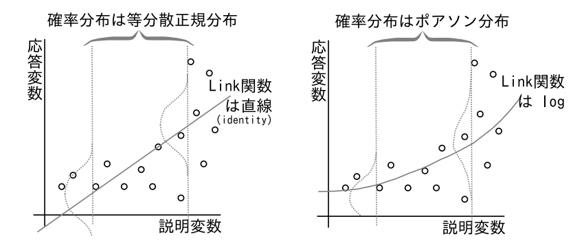

引用：[久保先生の講義のーと](https://eprints.lib.hokudai.ac.jp/dspace/bitstream/2115/49477/4/kubostat2008c.pdf)

- 応答変数がマイナス？
- 本当にばらつきが一定？（右側でばらつき増えてない？）

## もっと拡張性の高いモデリングをしよう

### **一般化線形モデル（Generalized linear model, GLM）**

- 線形モデル（単回帰、重回帰）を拡張した回帰分析
  - 目的変数は正規分布、二項分布、ポアソン分布など
  - 正規分布にした場合はlm()と同じ
  - lm()を使うより全部glmで解析するのがもはや一般的
- **誤差構造**と**リンク関数**を設定する
  - 誤差構造：目的変数の確率分布
  - リンク関数：目的変数と説明変数の関係 = 回帰式

## もっと拡張性の高いモデリングをしよう

### **一般化線形モデル（Generalized linear model, GLM）**

- glm(data = 【data.frame】, 【目的変数】~【説明変数】, family = 【誤差構造】(link = 【リンク関数】))
  - 誤差構造の設定でリンク関数は自動で決まる（変更可能）

| 誤差構造（family） | リンク関数（g(μ)） |
| --- | --- |
| 正規（gaussian） | μ |
| 二項 （binomial） | log(μ/(1-μ)) |
| ポアソン（poisson） | log(μ) |
| ガンマ （gamma） | 1/μ |

## 一般化線形モデルを使ってみよう

### 植物のサイズが種子数に及ぼす影響を調べよう

- 久保先生の[種子数データ](https://kuboweb.github.io/-kubo/ce/IwanamiBook.html)を解析しよう
- カウントデータ（離散値）は一般的に正規性を示さない

```r
seed= read_csv("https://kuboweb.github.io/-kubo/stat/iwanamibook/fig/poisson/data3a.csv") %>%
  rename(no.seed = y, plant_size = x, treatment = f)
head(seed)
```

```
## # A tibble: 6 x 3
##   no.seed plant_size treatment
##     <dbl>      <dbl> <chr>
## 1       6       8.31 C
## 2       6       9.44 C
## 3       6       9.5  C
## 4      12       9.07 C
## 5      10      10.2  C
## 6       4       8.32 C
```

## 一般化線形モデルを使ってみよう

### 植物のサイズが種子数に及ぼす影響を調べよう

- まずはプロットしてみる

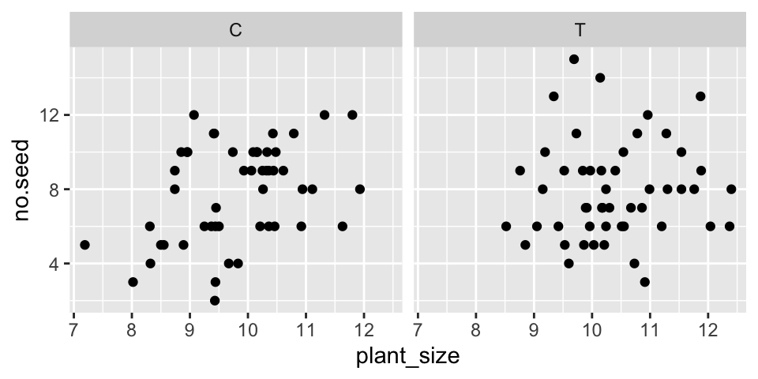

```r
gp = ggplot(data = seed) +
  geom_point(aes(x =plant_size , y = no.seed)) +
  facet_wrap(~treatment)
gp
```

- なんとなくサイズが大きいほうが種子数が多いような…？

## 一般化線形モデルを使ってみよう

### 植物のサイズが種子数に及ぼす影響を調べよう

- 一応正規性があるかどうか確認してみる

```r
sw_test_results = seed %>%   #seedを使う
  group_by(treatment) %>%    #treatmentでグループ
  summarise(statistic = shapiro.test(no.seed)$statistic,
        #no.seedにshapiro.testを行い、そのstatistic値をstatisticという列に
            p.value = shapiro.test(no.seed)$p.value,    #同様
            .groups     = "drop") #グループを解除
head(sw_test_results)
```

```
## # A tibble: 2 x 3
##   treatment statistic p.value
##   <chr>         <dbl>   <dbl>
## 1 C             0.948  0.0283
## 2 T             0.951  0.0359
```

- やっぱりない（Shapiroテストをするかは判断が分かれるところ）

## 値の関係性を調べよう

### **ポアソン分布（Poisson distribution）**

- ある時間間隔（λ）で発生する離散的な事象を数える特定の確率変数 X を持つ離散確率分布

[figure not shown]

- 以下のような理由から、上限のないカウントデータのモデリングに使われる
1. 値が非負の整数である {0, 1, 2, …}
2. yに下限（ゼロ）はある、上限はよくわからない
3. 平均と分散がだいたい等しい（データと合っているか検討の余地あり）

## 値の関係性を調べよう

### **ポアソン分布（Poisson distribution）**でGLMする

- glm(data = 【data.frame】, 【目的変数の列名】~【説明変数の列名】, family = poisson)
- デフォルトのリンク関数はlog
  - Y ~ exp(β0 + β1X)
  - 指数曲線に回帰される（0 < y < ∞）

## 一般化線形モデルを使ってみよう

### 植物のサイズが種子数に及ぼす影響を調べよう

```r
glm_result = glm(no.seed ~ plant_size, data = seed, family = poisson)
summary(glm_result)
```

```
##
## Call:
## glm(formula = no.seed ~ plant_size, family = poisson, data = seed)
##
## Deviance Residuals:
##     Min       1Q   Median       3Q      Max
## -2.3679  -0.7348  -0.1775   0.6987   2.3760
##
## Coefficients:
##             Estimate Std. Error z value Pr(>|z|)
## (Intercept)  1.29172    0.36369   3.552 0.000383 ***
## plant_size   0.07566    0.03560   2.125 0.033580 *
## ---
## Signif. codes:  0 '***' 0.001 '**' 0.01 '*' 0.05 '.' 0.1 ' ' 1
##
## (Dispersion parameter for poisson family taken to be 1)
##
##     Null deviance: 89.507  on 99  degrees of freedom
## Residual deviance: 84.993  on 98  degrees of freedom
## AIC: 474.77
##
## Number of Fisher Scoring iterations: 4
```

## 一般化線形モデルを使ってみよう

### 植物のサイズが種子数に及ぼす影響を調べよう

```r
glm_result = glm(no.seed ~ plant_size, data = seed, family = poisson)
summary(glm_result)
```

- 結果の見方はほぼ同じ
- Coefficients: 回帰係数
  - Estimates: 推定値
    - (Intercept): 切片
    - plant_size: plant_sizeの係数
  - Pr(>|t|): 回帰係数が0であるという帰無仮説に対するp値。
- Multiple R-squaredは計算されない
- ということは…
- Estimated coefficients of plant_size: 0.07566
- Pr(>|t|): 0.033580
- →種子数への植物サイズの効果は有意である（効果量は低いけどね）

## 一般化線形モデルを使ってみよう

### ggplotで描画もできる（geom_smooth, method = “glm”）

- method = glm #GLMを指定できる
- method.args = list(family = poisson) #分布を指定する

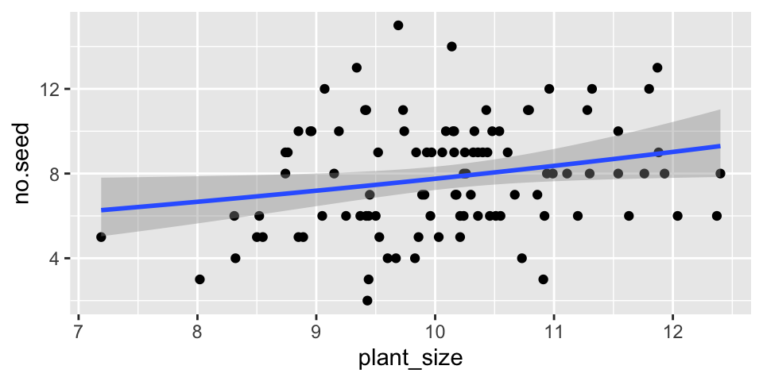

```r
gp = ggplot(data = seed) +
  geom_point(aes(x =plant_size , y = no.seed)) +
  geom_smooth(aes(x =plant_size , y = no.seed),
              method = glm, method.args = list(family = poisson))
gp
```

## 一般化線形モデルを使ってみよう

### 植物のサイズが種子の生存率に及ぼす影響を調べよう

- 久保先生の[種子の生存率データ](https://kuboweb.github.io/-kubo/ce/IwanamiBook.html)を解析しよう
- 上限のあるカウントデータ（離散値）も一般的に正規性を示さない

```r
seed2= read_csv("https://kuboweb.github.io/-kubo/stat/iwanamibook/fig/binomial/data4a.csv") %>%
  rename(observed_seed = N, survived_seed = y, plant_size = x, treatment = f)
head(seed2)
```

```
## # A tibble: 6 x 4
##   observed_seed survived_seed plant_size treatment
##           <dbl>         <dbl>      <dbl> <chr>
## 1             8             1       9.76 C
## 2             8             6      10.5  C
## 3             8             5      10.8  C
## 4             8             6      10.9  C
## 5             8             1       9.37 C
## 6             8             1       8.81 C
```

## 一般化線形モデルを使ってみよう

### 植物のサイズが種子の生存率に及ぼす影響を調べよう

- まずはプロットしてみる

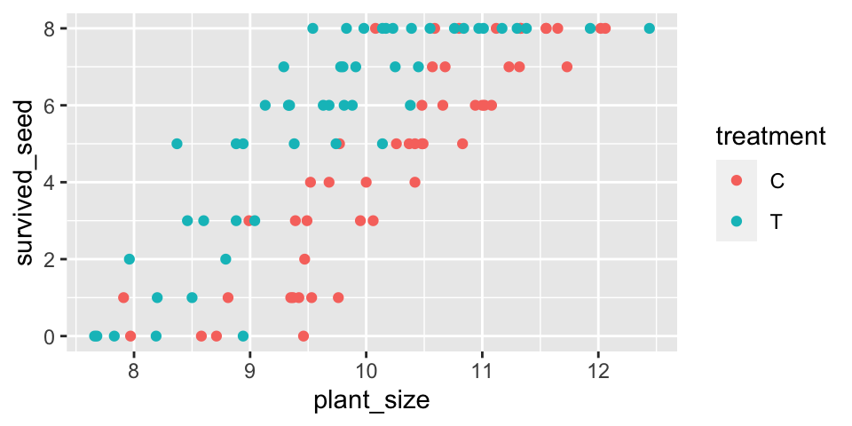

```r
gp = ggplot(data = seed2) +
  geom_point(aes(x = plant_size , y = survived_seed, color = treatment))
gp
```

- サイズが大きいほうが生存率が高いような…？
- treatmentでも違いがありそう

## 値の関係性を調べよう

### **二項分布（Binomial distribution）**

- 結果が成功か失敗のいずれかである試行を独立にn回行ったときの成功回数を確率変数とする離散確率分布

[figure not shown]

- 以下のような上限のあるカウントデータ（生存率など）のモデリングに使われる
1. 値が非負の整数である {0, 1, 2, …, N}
2. yに下限（ゼロ）、上限（最大値）がある

## 値の関係性を調べよう

### **二項分布（Binomial distribution）**でGLMする

- glm(data = 【dataframe】, Y ~ X, family = binomial)
  - 応答変数（２値データ）を示す整数からなる２列として
    - 各条件に関する成功数と失敗数の対データなど
  - 応答変数を示すfactor（2値）からなる１列として
    - 成功 or 失敗、0 or 1など
  - 詳しい使い方は[こちら](https://www.rdocumentation.org/packages/stats/versions/3.6.2/topics/glm)
- デフォルトのリンク関数はロジット（logit)
  - Y ~ 1/(1 + exp(-(β0 + β1X)))
  - シグモイド曲線に回帰される（0 < y < 1）

## 一般化線形モデルを使ってみよう

### 植物のサイズが種子の生存率に及ぼす影響を調べよう

- Yes or Noのカタチにする
- 生存した種子数（survived_seed）と死んだ種子数（dead_seed）の２値データ

```r
seed3 = seed2 %>%
  mutate(dead_seed = observed_seed-survived_seed)
head(seed3)
```

```
## # A tibble: 6 x 5
##   observed_seed survived_seed plant_size treatment dead_seed
##           <dbl>         <dbl>      <dbl> <chr>         <dbl>
## 1             8             1       9.76 C                 7
## 2             8             6      10.5  C                 2
## 3             8             5      10.8  C                 3
## 4             8             6      10.9  C                 2
## 5             8             1       9.37 C                 7
## 6             8             1       8.81 C                 7
```

## 一般化線形モデルを使ってみよう

### 植物のサイズが種子の生存率に及ぼす影響を調べよう

```r
glm_result = glm(cbind(survived_seed, dead_seed) ~ plant_size,
                 data = seed3, family = binomial)
summary(glm_result)
```

```
##
## Call:
## glm(formula = cbind(survived_seed, dead_seed) ~ plant_size, family = binomial,
##     data = seed3)
##
## Deviance Residuals:
##     Min       1Q   Median       3Q      Max
## -3.3998  -1.1536   0.2472   1.1787   3.1231
##
## Coefficients:
##             Estimate Std. Error z value Pr(>|z|)
## (Intercept) -13.7785     1.0773  -12.79   <2e-16 ***
## plant_size    1.4626     0.1107   13.21   <2e-16 ***
## ---
## Signif. codes:  0 '***' 0.001 '**' 0.01 '*' 0.05 '.' 0.1 ' ' 1
##
## (Dispersion parameter for binomial family taken to be 1)
##
##     Null deviance: 499.23  on 99  degrees of freedom
## Residual deviance: 217.17  on 98  degrees of freedom
## AIC: 364.35
##
## Number of Fisher Scoring iterations: 5
```

## 一般化線形モデルを使ってみよう

### 植物のサイズが種子の生存率に及ぼす影響を調べよう

```r
glm_result = glm(cbind(survived_seed, dead_seed) ~ plant_size,
                 data = seed3, family = binomial)
summary(glm_result)
```

- Estimated coefficients of plant_size: 1.4626
- Pr(>|t|): <2e-16
- →種子の生存率への植物サイズの効果は有意である
- treatmentの効果も考慮に入れてみよう

## 一般化線形モデルを使ってみよう

### 植物のサイズが種子の生存率に及ぼす影響を調べよう

```r
glm_result = glm(cbind(survived_seed, dead_seed) ~ plant_size + treatment,
                 data = seed3, family = binomial)
summary(glm_result)
```

```
##
## Call:
## glm(formula = cbind(survived_seed, dead_seed) ~ plant_size +
##     treatment, family = binomial, data = seed3)
##
## Deviance Residuals:
##     Min       1Q   Median       3Q      Max
## -3.2584  -0.7948   0.1753   0.8757   3.1589
##
## Coefficients:
##             Estimate Std. Error z value Pr(>|z|)
## (Intercept) -19.5361     1.4138  -13.82   <2e-16 ***
## plant_size    1.9524     0.1389   14.06   <2e-16 ***
## treatmentT    2.0215     0.2313    8.74   <2e-16 ***
## ---
## Signif. codes:  0 '***' 0.001 '**' 0.01 '*' 0.05 '.' 0.1 ' ' 1
##
## (Dispersion parameter for binomial family taken to be 1)
##
##     Null deviance: 499.23  on 99  degrees of freedom
## Residual deviance: 123.03  on 97  degrees of freedom
## AIC: 272.21
##
## Number of Fisher Scoring iterations: 5
```

## 一般化線形モデルを使ってみよう

### 植物のサイズが種子の生存率に及ぼす影響を調べよう

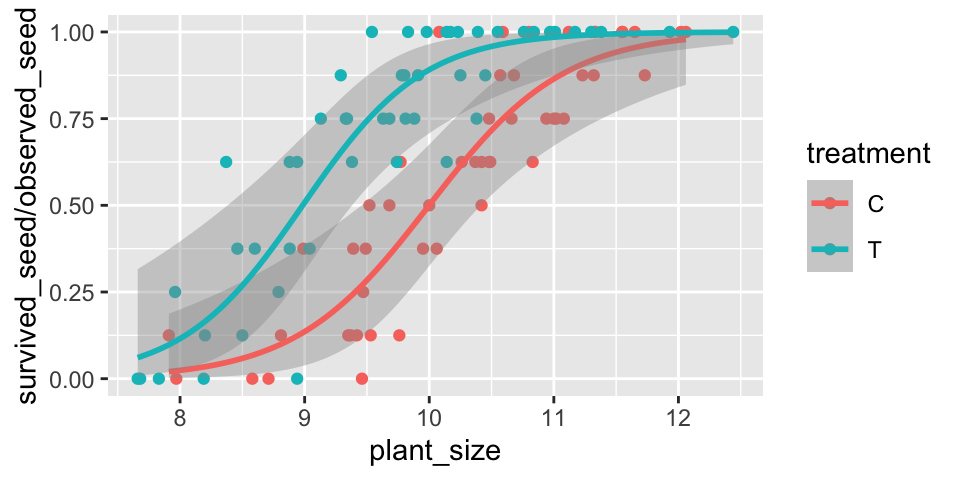

```r
gp = ggplot(data = seed2) +
  geom_point(aes(x = plant_size , y = survived_seed/observed_seed, color = treatment)) +
  geom_smooth(aes(x = plant_size , y = survived_seed/observed_seed, color = treatment),
               method = glm, method.args = list(family = binomial))
gp
```

## 一般化線形モデルを使ってみよう

### 低体重出生に母親の体重が与える影響を調べよう

- まずはinstall.packages(“MASS”)でインストール

```r
library(MASS)
head(birthwt)
```

```
##    low age lwt race smoke ptl ht ui ftv  bwt
## 85   0  19 182    2     0   0  0  1   0 2523
## 86   0  33 155    3     0   0  0  0   3 2551
## 87   0  20 105    1     1   0  0  0   1 2557
## 88   0  21 108    1     1   0  0  1   2 2594
## 89   0  18 107    1     1   0  0  1   0 2600
## 91   0  21 124    3     0   0  0  0   0 2622
```

## 一般化線形モデルを使ってみよう

### 低体重出生に母親の体重が与える影響を調べよう

- まずはinstall.packages(“MASS”)でインストール

```r
library(MASS)
head(birthwt)
```

- low:新生児の体重が2.5kg未満か否か(2.5kg未満が1)
- age:母親の年齢
- lwt:母親の体重(ポンド単位)
- smoke:母親の喫煙有無(喫煙有りが1)
- ptl:母親の早産経験の有無(経験有りが1)
- ht:母親の高血圧の有無(有りが1)
- ui:母親の子宮神経過敏の有(有りが1)

## 一般化線形モデルを使ってみよう

### 低体重出生に母親の体重が与える影響を調べよう

- まずはプロットしてみる

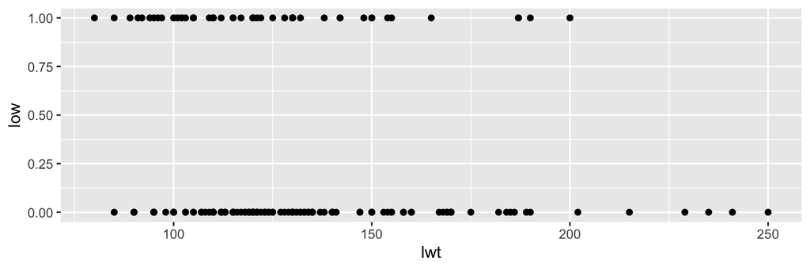

```r
gp = ggplot(data = birthwt, aes(x = lwt , y = low)) +
  geom_point()
gp
```

- 体重（lwt）が多いほうが低体重出生ではない（y = 0）傾向…？

## 一般化線形モデルを使ってみよう

### 低体重出生に母親の体重が与える影響を調べよう

```r
glm_result = glm(low ~ lwt,
                 data = birthwt, family = binomial)
summary(glm_result)
```

```
##
## Call:
## glm(formula = low ~ lwt, family = binomial, data = birthwt)
##
## Deviance Residuals:
##     Min       1Q   Median       3Q      Max
## -1.0951  -0.9022  -0.8018   1.3609   1.9821
##
## Coefficients:
##             Estimate Std. Error z value Pr(>|z|)
## (Intercept)  0.99831    0.78529   1.271   0.2036
## lwt         -0.01406    0.00617  -2.279   0.0227 *
## ---
## Signif. codes:  0 '***' 0.001 '**' 0.01 '*' 0.05 '.' 0.1 ' ' 1
##
## (Dispersion parameter for binomial family taken to be 1)
##
##     Null deviance: 234.67  on 188  degrees of freedom
## Residual deviance: 228.69  on 187  degrees of freedom
## AIC: 232.69
##
## Number of Fisher Scoring iterations: 4
```

## 一般化線形モデルを使ってみよう

### 低体重出生に母親の体重が与える影響を調べよう

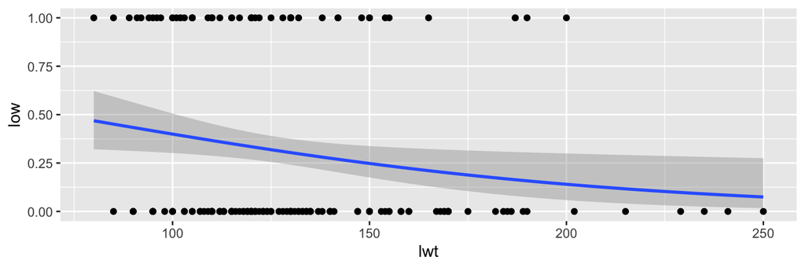

```r
gp = ggplot(data = birthwt, aes(x = lwt , y = low)) +
  geom_point() +
  geom_smooth(method = glm, method.args = list(family = binomial))
gp
```

- - 体重（lwt）が多いと有意に低体重出生率が低下する

## 【まとめ】統計モデリング

1. まずはプロット
2. 値の性質から誤差構造とリンク関数を推定する
   - 正規分布, ポアソン分布, 二項分布…
   - [使える分布](https://search.r-project.org/R/refmans/stats/html/family.html)は他にもある
   - ANOVA的な群間比較も行える（説明変数がfactor型なだけ）
3. 誤差構造とリンク関数を決めてGLMする
4. どのモデルがいちばん“良い”か
   - モデル選択(AICなど)

### **必要に応じて複雑なモデリングへ**

- *“All models are wrong, but some are useful”*